# Introduction to `MatchingPursuit` package

authors: Artur Gramacki and Jarosław Gramacki

## 1 R version and generation time

```
## R version:    4.6.2
## Generated on: 24-listopad-2026
```

## 2 Loading the package

```r
library(MatchingPursuit)
```

## 3 The purpose and functionality of the package

The presented package enables the analysis of time-series signals using the Matching Pursuit (MP) and Orthogonal Matching Pursuit (OMP) algorithms (see Mallat and Zhang (1993), Pati et al. (1993), Durka (2007), Elad (2010)). Additionally, it supports working with EEG (electroencephalogram) and ECG (electrocardiograph) signals. For multi-channel signals, each channel is decomposed independently; atoms are not selected jointly across channels.

The functionality of the package includes:

1. Native R implementations of:
   - **MP-Matrix** and **OMP-Matrix** for matrix-based dictionaries
   - **MP-Gabor** and **OMP-Gabor** for Gabor-based dictionaries
2. An educational and reference implementation of OMP through `omp_reference()`
3. Optional high-performance Gabor-based Matching Pursuit using the external **Enhanced Matching Pursuit Implementation (EMPI)** backend
4. Support for Gabor dictionaries via XML-based atom definitions
5. Support for biomedical signal formats
   - EDF and EDF+ file support
   - WFDB record support
   - Standard EEG montages (bipolar, referential, average-reference)
6. Visualization of time–frequency maps based on MP, OMP, and EMPI results
7. Signal pre-processing using notch, low-pass, high-pass, band-pass, and band-stop filters
8. Sparse decomposition using arbitrary user-defined dictionaries represented as numeric matrices

## 4 Naming convention

In this vignette, we use the following naming convention:

- **MP-Matrix** and **OMP-Matrix** refer to the native R implementations using matrix-based dictionaries.
- **MP-Gabor** and **OMP-Gabor** refer to the native R implementations using Gabor-based dictionaries.
- **MP** and **OMP** refer to the algorithms independently of any particular implementation.
- **EMPI** refers to the external Matching Pursuit implementation developed by Piotr T. Różański and available on [GitHub](https://github.com/develancer/empi).

## 5 Installing the optional EMPI backend

The below `empi_install()` function downloads **Enhanced Matching Pursuit Implementation** external program (or **EMPI** for short), see Różański (2024), and stores it in the cache directory. The function downloads the EMPI program in a version compatible with the operating system used (Windows, Linux, MacOS ARM64).

First, the user can check where EMPI will be downloaded from.

```r
empi_locate()
## $url
## [1] "https://github.com/develancer/empi/releases/download/1.0.4/empi-1.0.4-windows-x64.zip"
##
## $fname
## [1] "empi-1.0.4-windows-x64.zip"
```

The code in the below chunk has been commented out because CRAN’s verification rules prohibit automatic binary downloads. Therefore, this function cannot be executed while generating this vignette.

```r
# empi_install()
```

The user can check whether the EMPI program is installed; if not, an error message is displayed indicating that installation is required.

```r
tryCatch(
  empi_check(),
  error = function(e) message(conditionMessage(e))
)
## [1] "C:\\Users\\Artur\\AppData\\Local/R/cache/R/MatchingPursuit/empi/empi.exe"
```

Back to menu

## 6 Quick start

The following example demonstrates the native R MP/OMP workflow using `mp_omp_execute()`. The optional external EMPI-based workflow is presented afterwards.

### Step 1 - Input signal preparation

Let us construct an example signal by combining seven non-stationary components. The resulting signal (highlighted in blue below) will be used to demonstrate the basic functionality of the package.

```r
fs <- 1024
T <- 1
t <- seq(0, T - 1 / fs, 1 / fs)
N <- length(t)

# 7 non-stationary signals.
x1 <- sin(2 * pi * (10 + 40 * t) * t)                            # linear chirp
x2 <- sin(2 * pi * (20 * t^2) * t)                               # nonlinear chirp
x3 <- (1 + 0.5 * sin(2 * pi * 2 * t))  *  sin(2 * pi * 30 * t)   # AM
x4 <- sin(2 * pi * 50 * t + 5 * sin(2 * pi * 3 * t))             # FM
x5 <- exp(-2 * t)  *  sin(2 * pi * 60 * t)                       # decreasing amplitude
x6 <- sin(2 * pi * (5 + 20 * sin(2 * pi * t)) * t)               # frequency modulated sine wave
x7 <- t * sin(2 * pi * 40 * t)                                   # increasing amplitude

signal <- data.frame(x = x1 + x2 + x3 + x4 + x5 + x6 + x7)
```

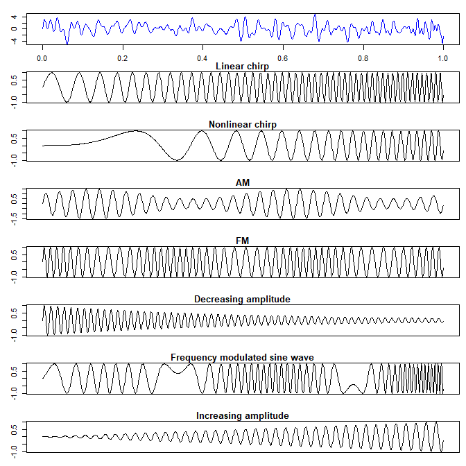

Data must be stored in a data frame: rows represent samples for all channels, and columns represent channels. Our first demo dataset consists of only one channel (one column). The `read_csv_signals()` function checks whether the data has the correct structure. The first line of the file must contain two numbers: the sampling rate in Hz (`freq`) and the signal length in seconds (`sec`). This allows verification that the file actually contains `freq*sec` samples.

```r
# The sample1.csv file contains exactly the same data as shown in Step 1.
file <- system.file("extdata", "sample1.csv", package = "MatchingPursuit")

# The first line of the file contains two values:
# the sampling rate in Hz (1024 Hz here) and the signal duration
# in seconds (1 s here).
out <- read.csv(file, header = FALSE)
head(out)
##           V1
## 1     1024 1
## 2 0.00000000
## 3 1.02492083
## 4 1.93756420
## 5 2.63875099
## 6 3.05949332

signal <- read_csv_signals(file)
signal
## Signal object (class 'sig')
## --------------------------------------------------
## Samples:            1024
## Channels:           1
## Sampling frequency: 1024 Hz
## Duration:           1 s
```

### Step 2 - Native R MP decomposition

The input data (`signal`) is passed as an argument to the `mp_omp_execute()` function, which generates the object of class `mp` containing all atom parameters.

For Gabor-based decomposition, `mp_omp_execute()` provides the high-level native R interface. It prepares a parameterized Gabor dictionary and performs iterative MP or OMP decomposition by selecting atoms against the current residual, without materializing the complete time-domain dictionary. It returns an object of class `"mp"`. In this example, classical Matching Pursuit is used; setting `mode = "omp"` runs Orthogonal Matching Pursuit instead.

```r
fit_mp <- mp_omp_execute(
  mode = "mp",
  signal = signal,
  n_nonzero_coefs = 25
)
## Processing channel 1/1 (MP)...
## Channel 1/1 completed.

summary(fit_mp)
## Summary of Matching Pursuit object (class 'mp')
## --------------------------------------------------------
## Samples:            1024
## Channels:           1
## Sampling frequency: 1024 Hz
## Duration:           1 s
##
## Per-channel decomposition:
## Relative residual energy = residual energy / signal energy
## Explained energy = 1 - relative residual energy
##
## Note:
## -----
## For MP, this measure is preferred because the reconstruction
## and residual are not generally orthogonal. Consequently, the
## ratio reconstruction energy / signal energy is not, in general,
## equal to the explained energy fraction.
##
## Channel 1:             25 atoms
## Signal energy:         2746.16
## Reconstruction energy: 2539.12
## Residual energy:       207.441
## Relative residual energy: 0.0755386
## Explained energy:      92.45%
```

### Step 3 - Time-frequency map

It is now time to generate the final time-frequency (T-F) map for the selected channel. To display the T–F map, you can also use `plot.mp()`, the `S3` method for the generic `plot()` function. This function requires an object of class `mp`, such as an object returned by `mp_omp_execute()` or `empi_execute()`.

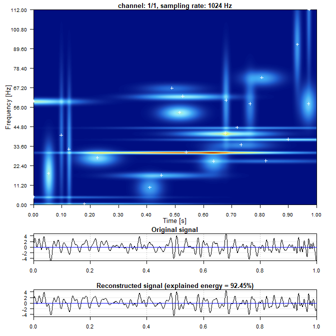

```r
plot(fit_mp)
```

By comparing the two signal waveforms below the T-F map, it can be seen that the original signal and the reconstructed signal differ only minimally. Also, basic signal parameters are displayed, along with information about the number of atoms into which the input signal was decomposed. Additionally, the energy of the input signal and the reconstructed signal (from the atoms) is calculated. The decomposition reduces the residual energy by 92.45% relative to the original signal energy. Naturally, increasing the number of generated atoms will likely bring the energy of the reconstructed signal closer to 100%.

Alternatively, you can use the `tf_map()` function to display a time-frequency map. The function provides greater control over the visualization process and offers additional functionality, such as saving time-frequency maps to a file. See the function documentation for details.

In the plot below, the centers of the atoms are marked with numbers indicating the order in which they were selected during decomposition. The color palette and the `mode`, `display_scale`, `db_range`, `shortening_factor_x`, and `shortening_factor_y` parameters have also been modified.

```r
out <- tf_map(
  x = fit_mp,
  channel = 1,
  freq_divide = 4,
  mode = "energy",
  display_scale = "db",
  db_range = 40,
  shortening_factor_x = 4,
  shortening_factor_y = 4,
  palette = "Inferno",
  reverse_palette = FALSE,
  atom_centers = "numbers"
)
```

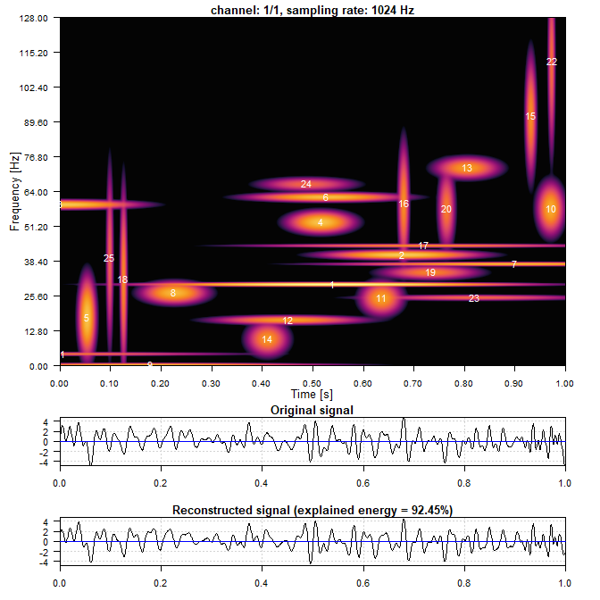

### Step 4 - Optional EMPI-based decomposition

The same signal can also be decomposed using the optional external Enhanced Matching Pursuit Implementation (EMPI) backend. Note that EMPI must be installed separately before `empi_execute()` can be used.

**Important note:** The code in the chunk below has been commented out because CRAN’s verification rules prohibit automatic binary downloads. `empi_execute()` function requires that EMPI is installed, otherwise it terminates with an error message. Therefore, this function cannot be executed here. This is why the output object from the `empi_execute()` has been generated in advance and included in the package as `rds` file. In the next chunk, the `plot()` and `tf_map()` functions use this file as input.

Notice the `empi_options` parameter in the `empi_execute()` function. You can omit this parameter, and the EMPI program will run with the default values set in the function (`"-o local --gabor -i 50"`). It is also worth noting that the EMPI program offers a wide range of configuration options. Details can be found in the `README.md` file located in the directory where the EMPI program was installed. In our example, parameters were set to instruct the program to find 25 atoms.

```r
# sample1_empi_out <- empi_execute(
#   signal = signal,
#   empi_options = "-o local --gabor -i 25",
# )

# saveRDS(sample1_empi_out, file = "sample1.rds")
```

Now, let’s load a previously generated result (stored in the `sample1.rds` file).

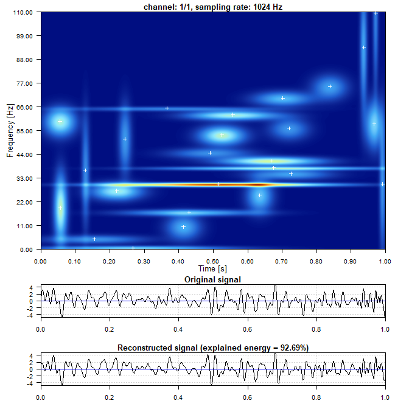

```r
file <- system.file("extdata", "sample1.rds", package = "MatchingPursuit")
sample1_empi_out <- readRDS(file = file)

plot(sample1_empi_out)
```

The T-F map is similar to the previous one, although some differences in atom selection can be observed. The decomposition reduces the residual energy by 92.69% relative to the original signal energy.

Back to menu

## 7 Electroencephalogram (EEG) analysis

In this section, we demonstrate how to analyze electroencephalography (EEG) signals using the Matching Pursuit algorithm. The package provides a dedicated function for reading files in EDF and EDF+ (European Data Format). It also supports three types of EEG montages and allows for signal filtering.

### Step 1 - Reading EEG data

Reading an example EEG signal (EDF file). The signal is 10 seconds long and consists of 20 channels (19 plus a special channel called the annotation channel that does not contain EEG signal data). The sampling rate is 256 Hz for each channel with EEG data. The channels have standard names.

```r
file <- system.file("extdata", "EEG.edf", package = "MatchingPursuit")

# Read signal parameters and display them in a tabular form.
eeg <- read_edf_signals(file)
signal_eeg <- eeg$signal
sampling_frequency <- eeg$sampling_frequency
time <- seq(0, nrow(signal_eeg) - 1) / sampling_frequency
```

### Step 2 - Filtering

EEG signals are rarely analyzed without prior filtering. Using the `design_filters()` function, you can define the filter parameters and then apply the filter to the signal. The filter parameters listed below use typical values recommended in the literature for EEG signal analysis.

```r
# Filter parameters that will be used (quite typical in filtering EEG signals).
fc <- design_filters(
   sampling_frequency = sampling_frequency,
   notch = c(49, 51),
   lowpass = 40,
   highpass = 1,
)

# Filtering input signals.
signal_eeg_f <- signal_eeg

for (m in 1:ncol(signal_eeg_f)) {
  signal_eeg_f[, m] = signal::filtfilt(fc$notch, signal_eeg[, m])      # 50Hz notch filter
  signal_eeg_f[, m] = signal::filtfilt(fc$lowpass, signal_eeg_f[, m])  # Low pass IIR Butterworth
  signal_eeg_f[, m] = signal::filtfilt(fc$highpass, signal_eeg_f[, m]) # High pass IIR Butterwoth
}
```

### Step 3 - Resampling

Sometimes it is necessary to change the sampling frequency (increase — *upsampling* or decrease — *downsampling*). In the example below, the original sampling frequency is reduced from 256 Hz to 128 Hz.

```r
signal_eeg_f_r <- resample_signal(signal = signal_eeg_f, p = 1, q = 2)
time_128 <- seq(0, nrow(signal_eeg_f_r) - 1) / (sampling_frequency / 2)
sampling_frequency_r <- 128
```

The effect of the preprocessing (filtering and resampling) is illustrated below. Although filtering removes baseline drift and high-frequency noise and downsampling reduces the sampling frequency, the overall morphology of the EEG waveform is well preserved.

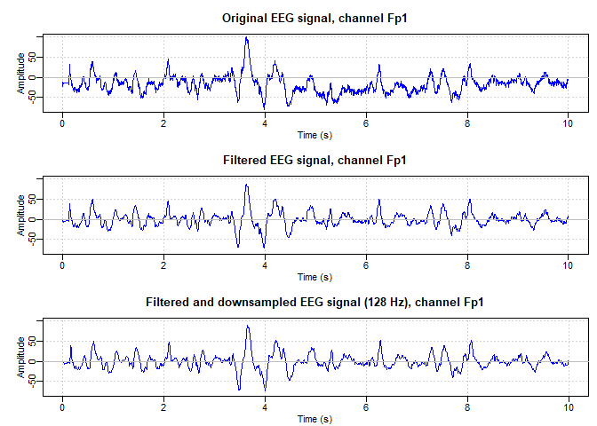

### Step 4 - Montage construction

A bipolar montage is created (the classical *double banana* montage), where each channel compares two adjacent electrodes. In the first step, you define the pairs of electrodes to be connected using the `pairs` list. In the second step, the `eeg_montage()` function generates the required montage.

```r
# Pairs of signals for bipolar montage (so called "double banana").
pairs <- list(
  c("Fp2", "F4"), c("F4", "C4"), c("C4", "P4"), c("P4", "O2"), c("Fp1", "F3"), c("F3", "C3"),
  c("C3", "P3"), c("P3", "O1"), c("Fp2", "F8"), c("F8", "T4"), c("T4", "T6"), c("T6", "O2"),
  c("Fp1", "F7"), c("F7", "T3"), c("T3", "T5"), c("T5", "O1"), c("Fz", "Cz"), c("Cz", "Pz")
)

# Make the bipolar montage.
signal_eeg_f_r_m <- eeg_montage(
  signal_eeg_f_r,
  montage_type = c("bipolar"),
  bipolar_pairs = pairs
)

# Original signal (first 6 rows, first 6 channels).
signal_eeg_f_r[1:6, 1:6]
##            Fp1         Fp2           F3           F4           F7           F8
## 1 -0.009169519 -0.00948931 -0.007902186 -0.009404775 -0.004150085 -0.006489879
## 2 -0.007879380 -0.02545971 -0.017611303 -0.019963222 -0.007967950 -0.027958014
## 3  0.078689947  0.17633851  0.135141209  0.153953511  0.073793375  0.189075962
## 4 -4.405347474 -5.25777306 -4.292400132 -5.062491209 -2.274244020 -4.099115184
## 5 -7.123860061 -9.75573535 -7.216335597 -8.494470758 -3.112619764 -7.582372940
## 6 -4.904350386 -7.37213153 -4.761021228 -5.880097268 -1.128596436 -5.172483701

# Signal after banana montage (first 6 rows, first 6 channels).
signal_eeg_f_r_m[1:6, 1:6]
##             Fp2_F4        F4_C4        C4_P4         P4_O2       Fp1_F3         F3_C3
## [1,] -8.453465e-05 -0.009038717 -0.003565737  0.0001613474 -0.001267334 -0.0003177297
## [2,] -5.496491e-03  0.030559501  0.005492579  0.0012699229  0.009731924 -0.0059268445
## [3,]  2.238500e-02 -0.150521483 -0.025526483 -0.0073991820 -0.056451262  0.0364474510
## [4,] -1.952819e-01 -2.676997475 -1.303608531  0.1215588493 -0.112947342 -0.4015900412
## [5,] -1.261265e+00 -2.573360624 -2.040162295  0.2925304240  0.092475536 -0.8818594888
## [6,] -1.492034e+00 -2.397153899 -1.985208885  0.2483389685 -0.143329158 -0.6516086820
```

### Step 5 - MP decomposition

```r
# For example decomposition, get only one channel.
sig <- as_sig(signal_eeg_f_r_m[, 2], sampling_frequency_r)

eeg_mp_out <- mp_omp_execute(
  mode = "mp",
  signal = sig,
  n_nonzero_coefs = 50
)
## Processing channel 1/1 (MP)...
## Channel 1/1 completed.
```

### Step 6 - Time-frequency map

Comparing the two signal waveforms under the T-F map, it can be seen that the original and reconstructed signals differ only minimally.

Below the plot, basic signal parameters are displayed, along with information about the number of atoms into which the input signal was decomposed.

Additionally, the energy of the input signal and the reconstructed signal (from the generated atoms) is calculated. The results show that nearly all of the energy of the original signal (95.98%) is “explained” by the generated atoms.

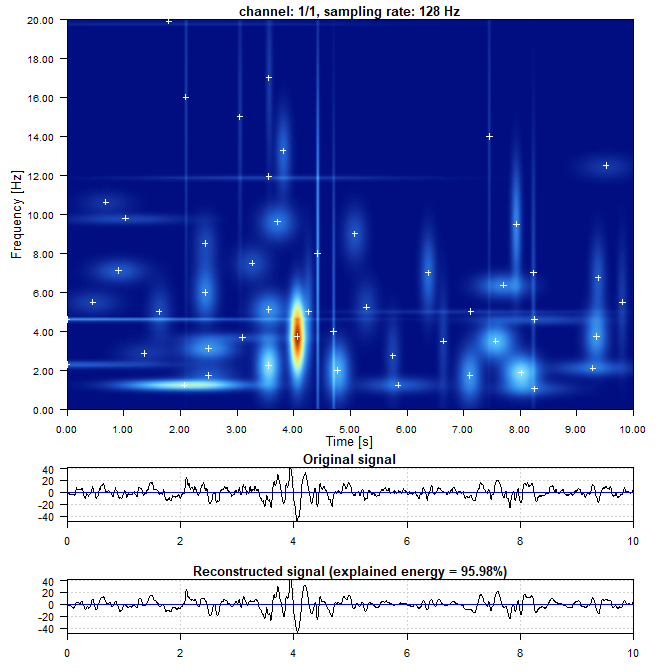

```r
plot(eeg_mp_out)
```

```r
summary(eeg_mp_out)
## Summary of Matching Pursuit object (class 'mp')
## --------------------------------------------------------
## Samples:            1280
## Channels:           1
## Sampling frequency: 128 Hz
## Duration:           10 s
##
## Per-channel decomposition:
## Relative residual energy = residual energy / signal energy
## Explained energy = 1 - relative residual energy
##
## Note:
## -----
## For MP, this measure is preferred because the reconstruction
## and residual are not generally orthogonal. Consequently, the
## ratio reconstruction energy / signal energy is not, in general,
## equal to the explained energy fraction.
##
## Channel 1:             50 atoms
## Signal energy:         121315
## Reconstruction energy: 119501
## Residual energy:       4882.77
## Relative residual energy: 0.0402488
## Explained energy:      95.98%
```

### Step 7 - Displaying EEG signals using `plot()` (optional)

The package also provides the `plot.edf()` function, an S3 method for `plot()` function, for visualization of multichannel EEG recordings. The function accepts an object of class `edf` returned by `read_edf_signals()` and displays the selected time interval using a conventional stacked EEG layout.

Since the preprocessing functions are designed to operate on generic multichannel signal matrices, they are independent of the `edf` class and can be applied to signals imported from different file formats. Therefore, before using `plot.edf()`, the processed signals are combined with the corresponding metadata into an object of class `edf`.

The `panel_height` argument controls the vertical spacing between adjacent channels. If it is `NULL`, an appropriate value is determined automatically to prevent overlap between signals. The selected value is reported in the R console.

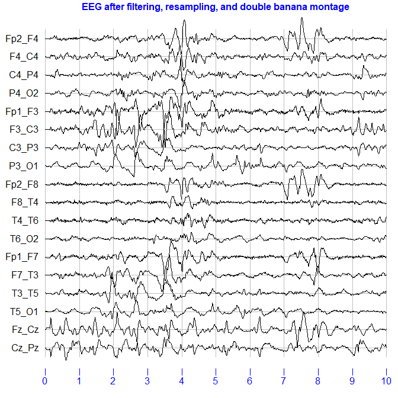

```
## Actual value of 'panel_height' parameter is: 67.5
```

```r
edf_processed <- structure(
  list(
    signal = as.data.frame(signal_eeg_f_r_m),
    sampling_frequency = sampling_frequency_r,
    time = time_128,
    signal_names = colnames(signal_eeg_f_r_m),
    record_name = basename(file)
  ),
  class = "edf"
)

plot(
  x = edf_processed,
  begin = 0,
  end = 10,
  panel_height = NULL,
  rainbow = FALSE,
  bg_colour = "white",
  txt_col = "blue",
  zero_line = TRUE,
  main = "EEG after filtering, resampling, and double banana montage"
)
```

The same approach can be used to visualize the original EEG recording before filtering, resampling, and montage construction.

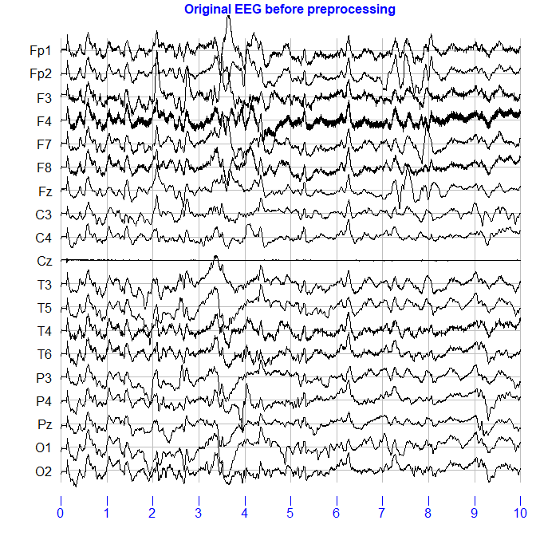

```
## Actual value of 'panel_height' parameter is: 75.5
```

```r
plot(
  x = eeg,
  begin = 0,
  end = 10,
  panel_height = NULL,
  rainbow = FALSE,
  bg_colour = "white",
  txt_col = "blue",
  zero_line = TRUE,
  main = "Original EEG before preprocessing"
)
```

Back to menu

## 8 Electrocardiography (ECG) analysis

In this section, we demonstrate how to analyze electrocardiography (ECG) signals using the Matching Pursuit algorithm. The package provides a dedicated function for reading files in WFDB (WaveForm DataBase) format. Once the ECG data has been loaded, further analysis is essentially the same as demonstrated in previous chapters.

### Step 1 - Reading ECG data

Reading an example ECG signal (`.dat` and `.hea` files). The signal is 10 seconds long and consists of 12 channels. The sampling rate is 100 Hz. The channels have standard names. The data comes from the repository available at [PhysioNet](https://physionet.org/content/ptb-xl/1.0.3/).

```r
file <- system.file("extdata", "00001_lr.hea", package = "MatchingPursuit")

out_ecg <- read_wfdb_signals(file)

head(out_ecg$signal)
##           I     II   III   AVR    AVL   AVF     V1     V2     V3     V4     V5     V6
## [1,] -0.119 -0.055 0.064 0.086 -0.091 0.004 -0.069 -0.031  0.000 -0.026 -0.039 -0.079
## [2,] -0.116 -0.051 0.065 0.083 -0.090 0.006 -0.064 -0.036 -0.003 -0.031 -0.034 -0.074
## [3,] -0.120 -0.044 0.076 0.082 -0.098 0.016 -0.058 -0.034 -0.010 -0.028 -0.029 -0.069
## [4,] -0.117 -0.038 0.080 0.077 -0.098 0.021 -0.050 -0.030 -0.015 -0.023 -0.022 -0.064
## [5,] -0.103 -0.031 0.072 0.066 -0.087 0.021 -0.045 -0.027 -0.020 -0.019 -0.018 -0.058
## [6,] -0.097 -0.025 0.071 0.061 -0.084 0.023 -0.036 -0.025 -0.009 -0.014 -0.012 -0.052
out_ecg$sampling_frequency
## [1] 100
out_ecg$lead_names
##  [1] "I"   "II"  "III" "AVR" "AVL" "AVF" "V1"  "V2"  "V3"  "V4"  "V5"  "V6"
out_ecg$record_name
## [1] "00001_lr"
```

### Step 2 - MP decomposition

The input data (`signal`) is passed as an argument to the `mp_omp_execute()` function, which generates the object of class `mp` containing all atom parameters.

```r
# For example decomposition, get only one channel.

out_ecg_1_channel <- out_ecg
out_ecg_1_channel$signal <- as.matrix(out_ecg$signal[, 1])
out_ecg_1_channel$lead_names <-  "I"

ecg_mp_out <- mp_omp_execute(
  mode = "mp",
  signal = out_ecg_1_channel
)
## Processing channel 1/1 (MP)...
## Channel 1/1 completed.

summary(ecg_mp_out)
## Summary of Matching Pursuit object (class 'mp')
## --------------------------------------------------------
## Samples:            1000
## Channels:           1
## Sampling frequency: 100 Hz
## Duration:           10 s
##
## Per-channel decomposition:
## Relative residual energy = residual energy / signal energy
## Explained energy = 1 - relative residual energy
##
## Note:
## -----
## For MP, this measure is preferred because the reconstruction
## and residual are not generally orthogonal. Consequently, the
## ratio reconstruction energy / signal energy is not, in general,
## equal to the explained energy fraction.
##
## Channel 1:             50 atoms
## Signal energy:         11.8881
## Reconstruction energy: 11.796
## Residual energy:       0.561905
## Relative residual energy: 0.0472661
## Explained energy:      95.27%
```

### Step 3 - Time-frequency map

It is now time to generate the final time-frequency (T-F) map for the selected channel.

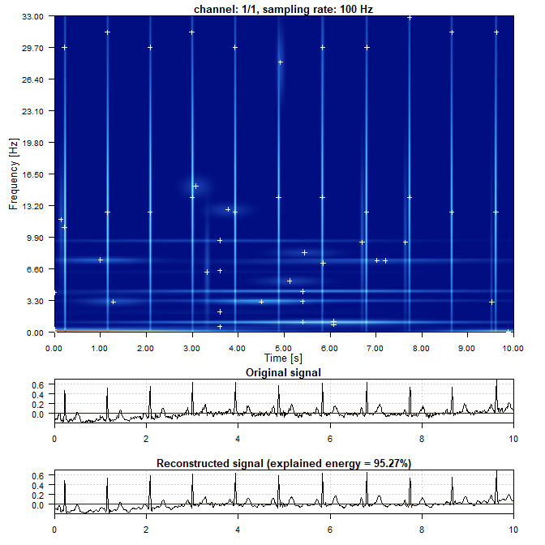

```r
# Create time-frequency map based on atoms.
out <- tf_map(
  x = ecg_mp_out,
  channel = 1,
  verbose = TRUE
)
## Channel number:             1
## Total channels:             1
## Number of atoms:            50
## Sampling frequency:         100 Hz
## Epoch size (in points):     1000
## Signal length (in seconds): 10
##
## Signal energy:              11.8881
## Reconstruction energy:      11.796
## Residual energy:            0.5619
## Explained_energy:           95.2734%
```

### Step 4 - ECG printout (optional)

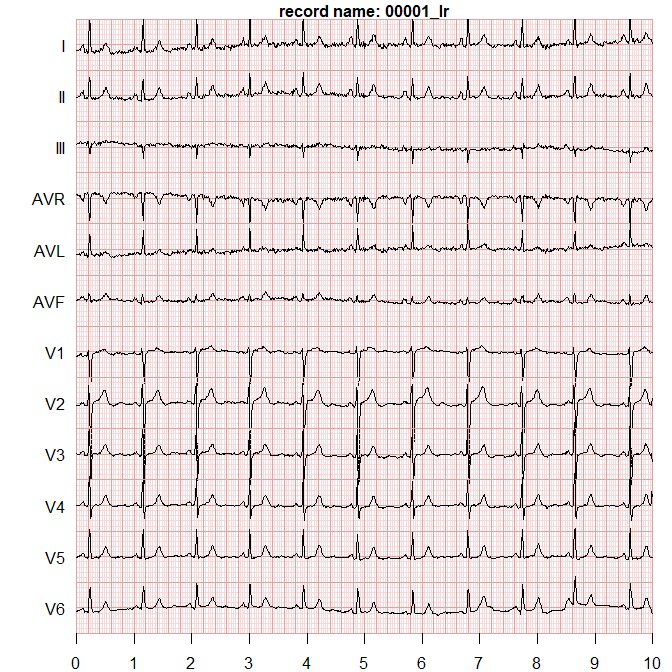

```r
plot(
  x = out_ecg,
  begin = 0,
  end = 10,
  panel_height = 1,
  zero_line = FALSE,
  small_squares = TRUE
)
```

Back to menu

## 9 Sparse decomposition of a synthetic multicomponent signal

In this chapter, we present a specific data example adapted from the work of Durka (2007). The signal consists of a mixture of seven components: (a) four Gabor functions with different parameters, (b) a unit impulse, (c) a sinusoidal waveform, and (d) a chirp signal where frequency varies continuously over time.

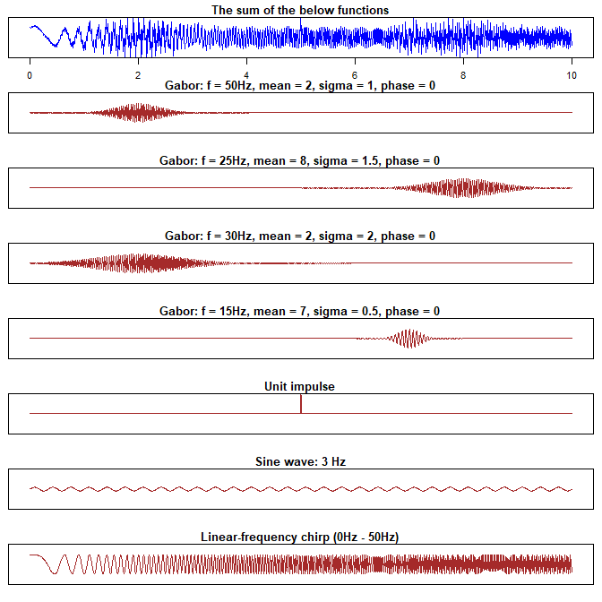

In the T–F map, all signal components—except for the chirp—are represented clearly and accurately (i.e., blobs for Gabor functions, a horizontal line for the sine wave, and a vertical line for the unit impulse). However, the chirp signal is decomposed into several separate blobs. This behavior arises from the discrete nature of the atom dictionary used in the Matching Pursuit algorithm, which prevents a continuous representation of a signal with smoothly varying frequency. This limitation (and, in some respects, a drawback) of the Matching Pursuit algorithm should be taken into account.

```r
sig_file <- system.file("extdata", "sample2.csv", package = "MatchingPursuit")
signal <- read_csv_signals(sig_file, col_names_in_csv = FALSE)

sample2_mp_omp_out <- mp_omp_execute (
  mode = "omp",
  signal = signal
)
## Processing channel 1/1 (OMP)...
## Channel 1/1 completed.
```

```r
out <- tf_map(
  x = sample2_mp_omp_out,
  channel = 1,
  freq_divide = 1,
  mode = "energy",
  display_scale = "db",
  db_range = 12
)
```

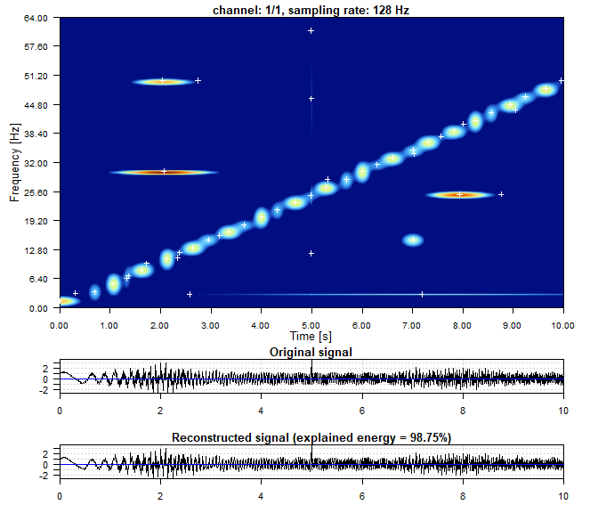

Back to menu

## 10 The Matching Pursuit algorithm in a nutshell

The Matching Pursuit algorithm is well-known and described in the literature. Its purpose is to approximate the analyzed signal using so-called atoms (the text below is adapted from Kunik and Gramacki (2025)).

Given a discrete signal $f \in \mathbb{R}^n$, and a possibly overcomplete dictionary $D =\{g_{\gamma}\}_{\gamma \in \Gamma}$ of normalized atoms $\|g_{\gamma}\|=1$ Matching Pursuit finds a sparse signal representation

$$f \approx \sum_{n = 0}^{N-1} a_n g_{\gamma_n},
\tag{1}$$
where $a_n \in \mathbb{R}$ are the expansion coefficients, $g_{\gamma_n} \in D$ are the selected atoms, and $N$ denotes the number of iterations performed by the algorithm. In practice, the decomposition may terminate earlier if a predefined stopping criterion is satisfied. In most practical cases $N \ll |D|$, where $|D|$ denotes the number of atoms in the dictionary. Also, $g_{\gamma}$ is the dictionary atom indexed by $\gamma$ and $\Gamma$ is the corresponding index set.

In the ideal case, the linear expansion (1) should include all atoms $g_{\gamma_n}$ that represent the relevant structures of the signal $f$. For real signals, such an ideal scenario is rarely possible, and some form of approximation is required. This task can be accomplished elegantly using the Matching Pursuit algorithm, which was first proposed by Mallat and Zhang (1993) in the context of signal processing.

Each atom $g_{\gamma}$ is typically a time-frequency shifted, scaled version of a prototype function, such as the Gabor function (often called a Gaussian-windowed sinusoid). The dictionary is constructed to cover a wide range of time and frequency characteristics. A continuous-time real-valued Gabor function can be written as

$$g_{\gamma}(t) =
K(\gamma) e^{- \pi \left( \frac{t-\mu}{\sigma} \right) ^2}
\cos(\omega (t - \mu) + \phi), \tag{2}$$

where $\gamma = (\mu, \omega, \sigma, \phi)$ denotes a point in a four-dimensional parameter space and $K(\gamma)$ is such that $||g_{\gamma}|| = 1$. It is easy to see that Gabor functions are constructed by multiplying Gaussian envelopes with cosine oscillations of different frequencies $\omega$ and phases offset $\phi$. By multiplying these two functions, we can obtain a wide variety of shapes depending on their parameters. A few examples of Gabor function are presented in figure below (in blue). The sinusoidal plane wave (in gray) is modulated by a Gaussian envelope (in red).

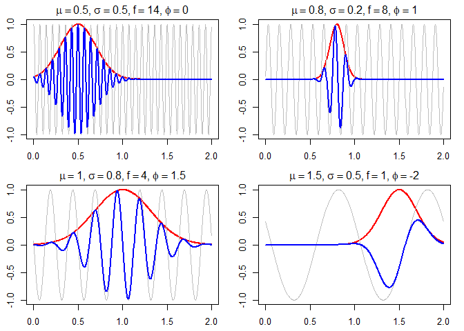

The Matching Pursuit (MP) algorithm is an iterative greedy algorithm for decomposing a signal into a sparse linear combination of atoms selected from a dictionary. In each iteration, MP selects an atom $g_{\gamma_n}$ from the dictionary $D$ that best matches the current residual signal $R^n$. Formally, at the beginning of the decomposition ($n=0$), the initial residual and signal approximation are given by

$$R^0 = f \tag{3}$$
and

$$f^0 = 0. \tag{4}$$

For each iteration $n = \{0,1,\ldots, N-1\}$, the atom $g_{\gamma_n} \in D$ maximizing the absolute inner product with the current residual is selected:

$$g_{\gamma_n} = \operatorname*{arg\,max}_{\gamma \in \Gamma} | \langle
R^{n}, g_{\gamma} \rangle |. \tag{5}$$
The coefficients $a_n$ in (1) are

$$a_n = \langle R^{n}, g_{\gamma_n} \rangle \tag{6}$$

and updated function approximation is defined as

$$f^{n+1} = f^{n} + a_n g_{\gamma_n}. \tag{7}$$

Similarly, updated residual is defined as

$$R^{n+1} = R^{n} - a_n g_{\gamma_n}. \tag{8}$$

Repeating this procedure yields a sequence of progressively improved signal approximations. After $N$ iterations, the signal $f$ is approximated as

$$f \approx \sum_{n = 0}^{N-1} \langle R^n, g_{\gamma_n} \rangle
g_{\gamma_n} = \sum_{n = 0}^{N-1} a_n g_{\gamma_n} \tag{9}$$

or equivalently

$$f = \sum_{n = 0}^{N-1} \langle R^n, g_{\gamma_n} \rangle g_{\gamma_n} +
R^{N}. \tag{10}$$

The procedure stops when $\|R^{n+1}\|_2$ falls below a predefined threshold or when a fixed number of iterations has been reached

Finding an optimal $N$-term approximation over a redundant dictionary is, in general, NP-hard. MP therefore employs a greedy strategy that provides an efficient approximate solution with substantially lower computational cost. Its main advantage is the relatively simple iterative structure and comparatively low computational cost.

However, once an atom has been selected according to (5), its coefficient is not re-estimated in subsequent iterations. Consequently, the coefficients of previously selected atoms may become suboptimal when additional correlated atoms are added to the approximation.

Because the selected atoms are normalized, each MP iteration removes an amount of squared $\ell_2$ energy equal to $|\langle R^n,g_{\gamma_n}\rangle|^2$ from the current residual. Consequently, the signal energy can be decomposed as

$$||f||^2_2 = \sum_{n = 0}^{N-1} |\langle R^n, g_{\gamma_n} \rangle |^2 +
||R^{N}||^2_2. \tag{11}$$

This identity is sometimes referred to as the energy conservation property of Matching Pursuit.

Back to menu

## 11 The Orthogonal Matching Pursuit algorithm in a nutshell

The package also provides an implementation of the Orthogonal Matching Pursuit (OMP) algorithm. The OMP algorithm is closely related to MP, but differs in how approximation coefficients are estimated.

In the classical MP algorithm, after an atom has been selected, only the residual signal is updated (8). The previously selected atoms and their coefficients remain unchanged and are not re-estimated in subsequent iterations.

OMP addresses this limitation by recomputing the coefficients of all selected atoms after each atom selection. As a result, the new residual is orthogonal to the subspace spanned by all selected atoms.

At each iteration, OMP selects the next atom $g_{\gamma_n}$ by maximizing its correlation with the current residual, as in (5). The crucial difference from MP lies in the subsequent estimation of the coefficients. After the new atom has been added to the selected set, the coefficients are obtained by solving a least-squares problem

$$\mathbf{a}^{(n)}
=
\operatorname*{arg\,min}_{\mathbf{c}}
\left\|
f - D_n \mathbf{c}
\right\|_2^2, \tag{12}$$

where $\mathbf{c}$ is the vector of coefficients associated with the selected atoms, and $D_n$ denotes the matrix whose columns are the atoms selected up to and including iteration $n$:

$$D_n =
[g_{\gamma_0},g_{\gamma_1},\ldots,g_{\gamma_n}]. \tag{13}$$

Assuming that $D_n$ has full column rank, the least-squares solution is

$$\mathbf{a}^{(n)}
=
(D_n^T D_n)^{-1}D_n^T f. \tag{14}$$
In the OMP implementation, this least-squares problem is solved efficiently using an incremental Cholesky factorization. Rather than recomputing the solution from scratch after each newly selected atom, the Cholesky factor is updated as the active dictionary grows, and the coefficients are obtained by forward and backward substitution.

The new residual is then calculated as

$$R^{n+1} = f - D_n \mathbf{a}^{(n)}. \tag{15}$$

Because the residual is orthogonal to the span of the selected atoms, its correlation with every selected atom is zero (in exact arithmetic). Consequently, a previously selected atom cannot be selected again.

Back to menu

## 12 Comparison of MP and OMP

Both MP and OMP use a greedy correlation-based strategy to select atoms from a dictionary. The main difference between the two algorithms lies in the way the coefficients associated with the selected atoms are estimated and the residual is updated. In MP, only the coefficient of the newly selected atom is estimated at each iteration, whereas OMP jointly re-estimates the coefficients of all atoms selected so far.

The main advantage of OMP is that, after solving the least-squares problem, the residual is orthogonal to the subspace spanned by all selected atoms. Consequently, the coefficients of previously selected atoms can be re-estimated when new atoms are added. In contrast, MP does not revisit previously estimated coefficients, which makes it computationally simpler. OMP often achieves a lower reconstruction error than MP for a given number of selected atoms, although this is not guaranteed for every signal and dictionary.

The choice between MP and OMP therefore represents a trade-off between computational efficiency and approximation accuracy. MP may be preferable when computational simplicity and speed are important, whereas OMP generally provides a more accurate reconstruction for a given number of selected atoms and may require fewer atoms to achieve a prescribed reconstruction accuracy. This improvement comes at the cost of higher computational complexity, since the coefficients of all selected atoms must be jointly updated after each iteration.

Back to menu

## 13 Pure R implementation of the MP and OMP algorithms

### Core MP and OMP functions

The native R implementation is built around two core functions, `mp_core()` and `omp_core()`, which implement the Matching Pursuit and Orthogonal Matching Pursuit algorithms, respectively. These functions form the general-purpose sparse decomposition layer of the package and are independent of any particular atom family or dictionary construction method.

Both functions operate on user-defined dictionaries represented as numeric matrices, with candidate atoms stored in columns. This design allows the core algorithms to be used not only within the Gabor-based workflow provided by the package, but also with arbitrary dictionaries constructed independently by the user.

To demonstrate that the core solvers are independent of the Gabor-specific workflow, the following examples use a simple user-defined matrix dictionary.

```r
dictionary <- matrix(
  c(
     0.098, -0.308, -0.342, -0.894,
     0.928,  0.674, -0.270,  0.283,
     0.145, -0.326,  0.810, -0.114,
    -0.170, -0.466,  0.377, -0.036,
     0.281, -0.357,  0.105, -0.327
  ),
  nrow = 5,
  byrow = TRUE
)

# Although mp_core() and omp_core() normalize dictionary atoms internally,
# the atoms are normalized explicitly here so that the coefficients used to
# construct the signal have a direct interpretation.
dictionary <- sweep(dictionary, 2, sqrt(colSums(dictionary^2)), "/")

# Signal constructed from two correlated dictionary atoms
signal <- 1.5 * dictionary[, 1] - 0.8 * dictionary[, 2]
```

After defining the dictionary and signal, the MP and OMP decompositions can be performed.

```r
fit_mp <- mp_core(
  dictionary = dictionary,
  signal = signal,
  n_nonzero_coefs = 2
)

fit_omp <- omp_core(
  dictionary = dictionary,
  signal = signal,
  n_nonzero_coefs = 2
)
```

The decomposition results can then be compared in terms of the selected atoms, estimated coefficients, and residual error.

```r
fit_mp$support
## [1] 1 2
fit_omp$support
## [1] 1 2

fit_mp$coefs
## [1]  1.0783989 -0.5778156
fit_omp$coefs
## [1]  1.5 -0.8

sum(fit_mp$residual^2)
## [1] 0.1283816
sum(fit_omp$residual^2)
## [1] 4.622232e-31
```

The two examples illustrate the different behavior of MP and OMP when dictionary atoms are correlated. Both algorithms identify the same relevant atoms, but OMP re-estimates all active coefficients after each new atom is added. As a result, OMP recovers the original coefficients more accurately and produces a smaller residual error. In contrast, MP updates the approximation sequentially and does not revise previously estimated coefficients, which can lead to a less accurate reconstruction for the same number of selected atoms.

### High-level decomposition interface

The `mp_omp_execute()` function provides a convenient high-level interface for Gabor-based decomposition. After loading the signal, the user only needs to select the decomposition mode and specify the main analysis parameters.

```r
sig_file <- system.file("extdata", "sample1.csv", package = "MatchingPursuit")
signal <- read_csv_signals(sig_file, col_names_in_csv = FALSE)
```

The decomposition can then be performed using either OMP or classical MP. The returned object is ready for direct visualization with `plot()`.

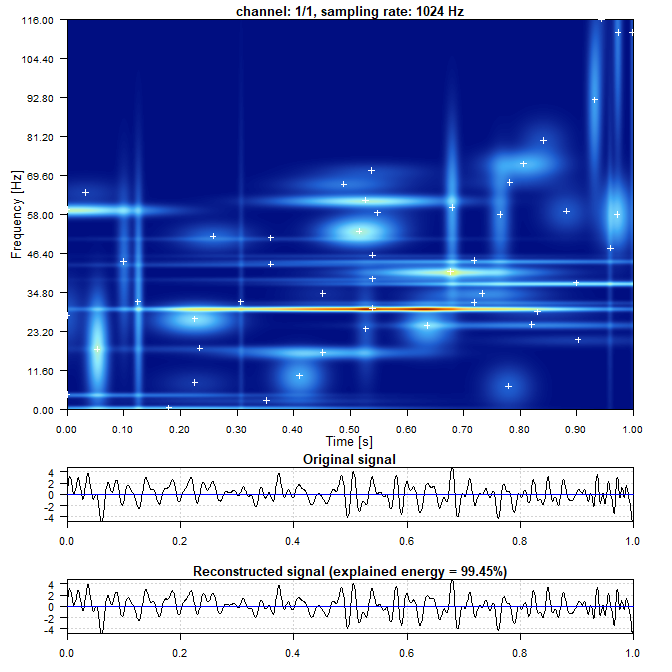

```r
fit <- mp_omp_execute(
   mode = 'omp',          # or "mp" for classical Matching Pursuit
   signal = signal,
   n_nonzero_coefs = 50,
   verbose = FALSE
 )
## Processing channel 1/1 (OMP)...
## Channel 1/1 completed.

plot(fit)
```

### Gabor dictionary preparation

For educational and experimental purposes, the dictionary preparation steps performed internally by `mp_omp_execute()` can also be carried out explicitly. These include generating an XML file containing the dictionary parameters using `generate_xml_dict()` and reading it with `read_gabor_dict()`. The resulting parameterized dictionary can be passed directly to `mp_core_gabor()` or `omp_core_gabor()` for iterative decomposition.

```r
sampling_frequency <- signal$sampling_frequency
signal_length <- nrow(signal$signal)
duration <- nrow(signal$signal) / sampling_frequency

xml_file <- tempfile(fileext = ".xml")

dict <- generate_xml_dict(
   N = signal_length,
   file = xml_file
)
```

### Reading the Gabor dictionary

The `read_gabor_dict()` function reads the XML-based dictionary specification and returns the corresponding candidate Gabor atom definitions. Depending on the specification, the resulting set may contain tens or hundreds of thousands of candidate atoms. For format details, see the section **XML-based atom dictionary specification**.

```r
atoms_dict <- read_gabor_dict(
  xml_file = xml_file,
  sampling_frequency = sampling_frequency,
  duration = duration,
  full_atoms_in_signal = FALSE,
  verbose = FALSE
)

dim(atoms_dict)
## [1] 322154      7
head(atoms_dict)
##      block time_sample   time_sec freq_bin freq_hz window_len fft_size
## [1,]     1          -8 -0.0078125        0       0         17       64
## [2,]     1          -8 -0.0078125        1      16         17       64
## [3,]     1          -8 -0.0078125        2      32         17       64
## [4,]     1          -8 -0.0078125        3      48         17       64
## [5,]     1          -8 -0.0078125        4      64         17       64
## [6,]     1          -8 -0.0078125        5      80         17       64
```

### Iterative Gabor atom selection

The parameterized dictionary is passed directly to `mp_core_gabor()` or `omp_core_gabor()`. At each iteration, candidate atoms are evaluated against the current residual using FFT-based projections and analytical phase optimization. Only the selected atoms are constructed in the time domain, without materializing the full dictionary matrix.

```r
fit_gabor <- mp_core_gabor(
  atoms_dict = atoms_dict,
  signal = signal,
  channel = 1,
  n_nonzero_coefs = 10,
  verbose = FALSE
)

fit_gabor$n_iters
## [1] 10
fit_gabor$relative_residual_energy
##  [1] 1.0000000 0.7802367 0.7108414 0.6446479 0.5860832 0.5276070 0.4758868 0.4262993 0.3814228 0.3466644 0.3125059
```

### Validation using a synthetic sparse signal

To validate the behavior of the general sparse decomposition solvers, we use a synthetic signal with a known sparse representation. The procedure applies to both MP and OMP; here, OMP is used as a representative example.

First we construct the dictionary. The dictionary contains sinusoidal atoms at several frequencies, while only three atoms are used to generate the signal. This allows the selected atoms, estimated coefficients, and reconstruction error to be compared directly with the known ground truth.

Each column of the matrix represents one dictionary atom. The atoms are normalized to unit L2 norm so that the coefficients used to generate the signal can be compared directly with the coefficients estimated by OMP.

```r
set.seed(1)

N <- 256
t <- (0:(N - 1)) / N

dictionary <- cbind(
  sin(2 * pi * 3  * t),  cos(2 * pi * 3  * t),  sin(2 * pi * 7  * t),
  cos(2 * pi * 7  * t),  sin(2 * pi * 12 * t),  cos(2 * pi * 12 * t),
  sin(2 * pi * 20 * t),  cos(2 * pi * 20 * t)
)

# Unit-L2 normalization of dictionary atoms.
dictionary <- sweep(dictionary, 2, sqrt(colSums(dictionary^2)), "/")

colnames(dictionary) <- c(
  "sin_3", "cos_3",  "sin_7", "cos_7",
  "sin_12", "cos_12",  "sin_20", "cos_20"
)
```

Second, we generate a signal with known sparse representation. The signal is generated using only three non-zero coefficients. Therefore, the true support consists of the atoms `cos_3`, `sin_12`, and `cos_20`.

```r
true_coef <- c(0, 1.5, 0, 0, -0.8, 0, 0, 0.5)
true_atoms <- c("cos_3", "sin_12", "cos_20")

signal <- as.vector(dictionary %*% true_coef)
```

Now, we can do the OMP decomposition. Because the signal was generated exactly from three dictionary atoms, OMP should recover the same support and the corresponding coefficients.

```r
out <- omp_core(
  dictionary = dictionary,
  signal = signal,
  n_nonzero_coefs = 3
)

colnames(out$selected_atoms)
## [1] "cos_3"  "sin_12" "cos_20"

out$coefs
## [1]  1.5 -0.8  0.5
```

For the noise-free signal, the selected support should match the known support and the relative reconstruction error should be close to zero. The reconstruction error is at the level of numerical precision, indicating exact recovery of the noise-free signal.

```r
setequal(colnames(out$selected_atoms), true_atoms)
## [1] TRUE

relative_error <- sqrt(sum((signal - out$reconstruction)^2)) / sqrt(sum(signal^2))
relative_error
## [1] 7.450704e-16
```

Now, we can examine the robustness to additive noise. The noisy example demonstrates whether the same sparse support can still be identified when the observed signal is perturbed. Since the clean signal is known in this synthetic example, the reconstructed signal can also be compared directly with the noise-free ground truth.

```r
signal_noisy <- signal + rnorm(N, sd = 0.1)

out_noisy <- omp_core(
  dictionary = dictionary,
  signal = signal_noisy,
  n_nonzero_coefs = 3
)

colnames(out_noisy$selected_atoms)
## [1] "cos_3"  "sin_12" "cos_20"

out_noisy$coefs
## [1]  1.6412326 -0.7505156  0.3159247

setequal(colnames(out_noisy$selected_atoms), true_atoms)
## [1] TRUE
```

Despite additive Gaussian noise, OMP recovered the same three-atom support, while the reconstruction remained close to the known clean signal.

```r
relative_residual_error <- sqrt(
  sum((signal_noisy - out_noisy$reconstruction)^2)
  ) / sqrt(sum(signal_noisy^2))

relative_residual_error
## [1] 0.6353605

relative_clean_error <- sqrt(
  sum((signal - out_noisy$reconstruction)^2)
  ) / sqrt(sum(signal^2))

relative_clean_error
## [1] 0.1338779
```

### Relationship between MP-Matrix, OMP-Matrix, MP-Gabor, OMP-Gabor, and EMPI backends

The package provides four native R implementations: MP-Matrix and OMP-Matrix for matrix-based dictionaries, and MP-Gabor and OMP-Gabor for parameterized Gabor dictionaries. EMPI is an external high-performance C++ implementation of Gabor-based Matching Pursuit.

The diagram below summarizes the **three available decomposition workflows** and their relationship within the package. Blue boxes denote R functions, whereas peach boxes represent workflow components, inputs, or returned objects. Panel (b) shows the main steps performed internally by `mp_omp_execute()`.

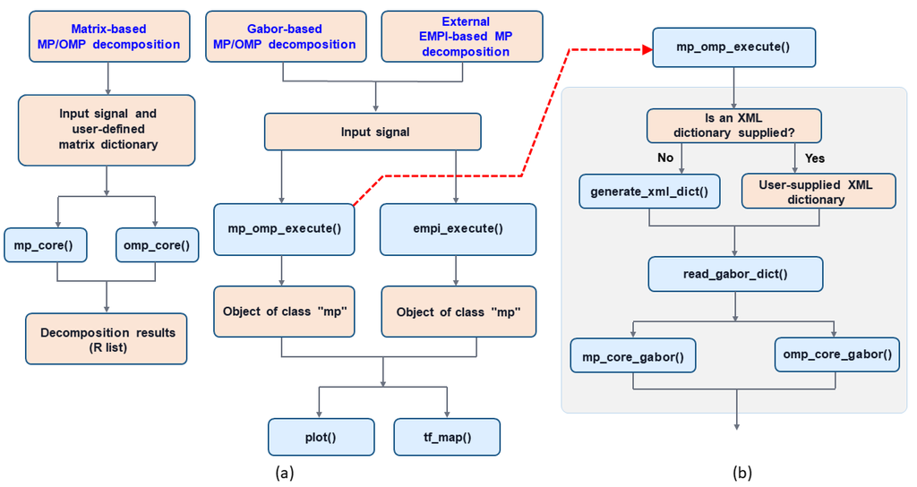

The **MP-Matrix / OMP-Matrix workflow** operates directly on a user-defined numeric dictionary and input signal through `mp_core()` or `omp_core()`. It is independent of the Gabor-specific dictionary construction utilities and can therefore be used with arbitrary matrix dictionaries. These functions return low-level decomposition results, giving the user direct control over the dictionary and the decomposition procedure.

The **MP-Gabor / OMP-Gabor workflow**, implemented by `mp_omp_execute()`, provides a higher-level interface for Gabor-based MP and OMP decomposition. It integrates dictionary specification or generation, dictionary reading, iterative atom selection against the current residual, and aggregation of channel-specific results into an object of class `"mp"`. If no XML dictionary specification is supplied, `generate_xml_dict()` creates one internally; otherwise, the user-provided XML file is used. The specification is processed by `read_gabor_dict()` to construct a parameterized dictionary, which is passed directly to `mp_core_gabor()` or `omp_core_gabor()`. These functions use FFT-based candidate evaluation and analytical phase optimization, materializing only the selected time-domain atoms rather than the complete dictionary.

The **EMPI workflow** provides an alternative MP implementation through `empi_execute()`. In this case, decomposition is performed by the external high-performance C++ EMPI backend rather than by the native R MP/OMP core functions. The wrapper integrates the external decomposition results into the same package-level `"mp"` representation, allowing them to be handled using the same downstream visualization functions, including `plot()` and `tf_map()`.

Thus, the three workflows differ mainly in the **dictionary representation and decomposition backend**: direct matrix-based MP/OMP for arbitrary user-defined dictionaries, the integrated native Gabor MP/OMP workflow, and the external EMPI-based Gabor MP workflow. The latter two return a common `"mp"` object, facilitating consistent visualization and interpretation within the package.

Back to menu

## 14 XML-based atom dictionary specification

The XML file encodes the structure of a dictionary of basis functions (Gabor atoms), including window lengths, window shifts, and frequency grids used during signal analysis. A simple example illustrates how atom parameters are encoded in the XML file. Consider the following **block**:

```
<block>
<param name="windowLen" value="17"/>
<param name="windowShift" value="1"/>
<param name="fftSize" value="32"/>
</block>
```

Assume that the analyzed signal is sampled at $1\;024$ Hz and has a duration of $1$ second. We define:

- Sampling frequency: ($f_s = 1\;024\ \text{Hz}$)
- Signal duration: ($T = 1\ \text{sec.}$)
- Number of samples: ($N = 1\;024$)
- Window length: ($L = 17$)
- Window shift: ($S = 1$)
- FFT size: $32$

### Number of window positions

With a shift of one sample ($S = 1$), the number of possible window positions is

$$N_{\text{windows}} = N - L + 1 = 1\;024 - 17 + 1 = 1\;008$$

### Number of frequency bins

For an FFT size of $32$, and because the analyzed signal is real-valued, it is sufficient to consider the non-negative frequencies from 0 to the Nyquist frequency. Thus, the number of frequency bins is

$$N_{\text{freq}} = \frac{32}{2} + 1 = 17$$
For a sampling frequency of $1024$ Hz, the frequency resolution is

$$\Delta f = \frac{1024}{32} = 32\ \text{Hz}.$$

Therefore, the frequencies are:

$$0, 32, 64, 96, 128, 160, 192, 224, 256, 288, 320, 352, 384, 416, 448,
480, 512\ \text{Hz}$$

### The total number of atoms

$$N_{\text{atoms}} = N_{\text{windows}} \times N_{\text{freq}}
= 1\;008 \times 17 = 17\;136$$

In other words, for each of the $1\;008$ possible positions of the $17$-sample window, $17$ atoms corresponding to different FFT frequencies are generated.

### Multiple-block dictionaries

A practical dictionary usually consists of multiple blocks with different window lengths, shifts, and FFT sizes. The calculations for each block are analogous to those shown above. The results for the example dictionary are summarized in the table below. As above, the sampling frequency is ($f_s = 1\;024\ \text{Hz}$) and the signal duration is ($T = 1\ \text{sec.}$), giving the number of samples ($N = 1\;024$). In total, the XML file defines parameters for $185\;365$ atoms.

```
<?xml version="1.0" encoding="ISO-8859-1"?>
<dict>
<block>
<param name="windowLen" value="17"/>
<param name="windowShift" value="1"/>
<param name="fftSize" value="32"/>
</block>
<block>
<param name="windowLen" value="27"/>
<param name="windowShift" value="1"/>
<param name="fftSize" value="64"/>
</block>
<block>
<param name="windowLen" value="41"/>
<param name="windowShift" value="2"/>
<param name="fftSize" value="128"/>
</block>
<block>
<param name="windowLen" value="65"/>
<param name="windowShift" value="3"/>
<param name="fftSize" value="128"/>
</block>
<block>
<param name="windowLen" value="103"/>
<param name="windowShift" value="6"/>
<param name="fftSize" value="256"/>
</block>
<block>
<param name="windowLen" value="163"/>
<param name="windowShift" value="9"/>
<param name="fftSize" value="512"/>
</block>
<block>
<param name="windowLen" value="259"/>
<param name="windowShift" value="15"/>
<param name="fftSize" value="512"/>
</block>
<block>
<param name="windowLen" value="409"/>
<param name="windowShift" value="24"/>
<param name="fftSize" value="1024"/>
</block>
<block>
<param name="windowLen" value="647"/>
<param name="windowShift" value="39"/>
<param name="fftSize" value="2048"/>
</block>
<block>
<param name="windowLen" value="1023"/>
<param name="windowShift" value="61"/>
<param name="fftSize" value="2048"/>
</block>
<block>
<param name="windowLen" value="1619"/>
<param name="windowShift" value="97"/>
<param name="fftSize" value="4096"/>
</block>
</dict>
```

| windowLen | windowShift | fftSize | number of windows | number of frequencies | number of atoms |
| --- | --- | --- | --- | --- | --- |
| 17 | 1 | 32 | 1008 | 17 | 17 136 |
| 27 | 1 | 64 | 998 | 33 | 32 934 |
| 41 | 2 | 128 | 492 | 65 | 31 980 |
| 65 | 3 | 128 | 320 | 65 | 20 800 |
| 103 | 6 | 256 | 154 | 129 | 19 866 |
| 163 | 9 | 512 | 96 | 257 | 24 672 |
| 259 | 15 | 512 | 52 | 257 | 13 364 |
| 409 | 24 | 1024 | 26 | 513 | 13 338 |
| 647 | 39 | 2048 | 10 | 1025 | 10 250 |
| 1023 | 61 | 2048 | 1 | 1025 | 1 025 |
| 1619 | 97 | 4096 | 0 | 2049 | 0 |

The last two blocks illustrate special cases:

```
<block>
<param name="windowLen" value="1023"/>
<param name="windowShift" value="61"/>
<param name="fftSize" value="2048"/>
</block>
<block>
<param name="windowLen" value="1619"/>
<param name="windowShift" value="97"/>
<param name="fftSize" value="4096"/>
</block>
```

The last two blocks illustrate a boundary case resulting from the finite signal length. For `windowLen` = $1\;023$, the window can be placed only once within the 1024-sample signal, resulting in $1\;025$ atoms corresponding to the available frequency bins. For the final block (`windowLen` = $1\;619$), the window length exceeds the signal length, so no fully contained atom can be generated. This behavior follows directly from the `full_atoms_in_signal = TRUE` convention, under which only atoms whose complete support lies within the signal boundaries are included.

A regular pattern can be observed in the dictionary construction: the ratio of `windowShift` to `windowLen` is nearly constant across all blocks (approximately 0.06). This means that consecutive windows overlap by about 94%.

Furthermore, as the window length increases, the frequency resolution also increases. This is a direct consequence of the time–frequency uncertainty principle - the longer the window, the better the ability to distinguish closely spaced frequencies, but at the expense of time localization.

Therefore, it is beneficial to analyze a larger number of frequency components for long windows, as they provide meaningful frequency information. In contrast, for short windows, a very dense frequency grid would not contribute much additional information because the frequency resolution is fundamentally limited by the window length itself.

In summary, the dictionary provides an approximately uniform coverage of the time–frequency plane - short windows are associated with many temporal positions and relatively few frequency bins, whereas long windows have fewer time positions but a much denser frequency sampling.

Back to menu

## 15 XML-based atom dictionary generator

The package includes a utility for generating XML-based atom dictionaries for MPTK-like sparse decomposition algorithms. The generator creates multiscale Gabor dictionaries with logarithmically distributed window lengths, automatically selecting window shifts and FFT sizes for each atom scale.

The generated dictionaries support multiresolution signal analysis by combining short atoms for transient components and long atoms for slowly varying structures. The XML specification may include atom scales longer than the analyzed signal. Whether such atoms are retained during dictionary construction depends on the `full_atoms_in_signal` setting. When `full_atoms_in_signal = TRUE`, only atoms fully contained within the signal are included; otherwise, longer atoms may be handled using zero-padding.

```r
# Generate a dictionary for a 512-sample signal
xml_file <- tempfile(fileext = ".xml")

dict <- generate_xml_dict (
   N = 512,
   file = xml_file,
   max_window_length = "3N"
)

dict
##    windowLen windowShift fftSize
## 1         17           1      64
## 2         27           2      64
## 3         39           2     128
## 4         59           4     128
## 5         89           5     256
## 6        133           8     512
## 7        199          12     512
## 8        301          18    1024
## 9        449          27    1024
## 10       677          41    2048
## 11      1021          61    2048
## 12      1535          92    4096
```

The generated XML specification may contain atom scales longer than the analyzed signal. Whether such atoms are retained depends on the `full_atoms_in_signal` argument used when the dictionary specification is read.

```r
# Read the dictionary specification and retain only atoms
# fully contained within the analyzed signal
dict_full <- read_gabor_dict(
   xml_file = xml_file,
   sampling_frequency = 256,
   duration = 2,
   full_atoms_in_signal = TRUE,
   verbose = FALSE
)

dict_padded <- read_gabor_dict(
   xml_file = xml_file,
   sampling_frequency = 256,
   duration = 2,
   full_atoms_in_signal = FALSE,
   verbose = FALSE
)

dim(dict_full)
## [1] 85137     7
dim(dict_padded)
## [1] 150558      7
```

With `full_atoms_in_signal = TRUE`, only atoms whose complete support lies within the analyzed signal are retained, resulting in $85\;137$ candidate atoms. When `full_atoms_in_signal = FALSE`, atoms extending beyond the signal boundaries are also allowed through zero-padding, increasing the dictionary size to $150\;558$ atoms. The difference is particularly pronounced for short signals, for which long atom scales have relatively few positions that are fully contained within the signal boundaries.

Back to menu

## 16 Bibliography

Durka, P. 2007. *Matching Pursuit and Unification in EEG Analysis*. Engineering in Medicine and Biology. Artech House.

Elad, M. 2010. *Sparse and Redundant Representations: From Theory to Applications in Signal and Image Processing*. Springer. https://doi.org/10.1007/978-1-4419-7011-4.

Kunik, M., and A. Gramacki. 2025. “Deep Learning Epileptic Seizure Detection based on the Matching Pursuit Algorithm and its Time–Frequency Graphical Representation.” *International Journal of Applied Mathematics and Computer Science* 35 (4): 617–30. https://doi.org/10.61822/amcs-2025-0044.

Mallat, S., and Z. Zhang. 1993. “Matching Pursuits With Time-Frequency Dictionaries.” *IEEE Transactions on Signal Processing* 41 (12): 3397–415. https://doi.org/10.1109/78.258082.

Pati, Y. C., R. Rezaiifar, and P. S. Krishnaprasad. 1993. “Orthogonal Matching Pursuit: Recursive Function Approximation with Applications to Wavelet Decomposition.” *Proceedings of the 27th Asilomar Conference on Signals, Systems and Computers*, 40–44. https://doi.org/10.1109/ACSSC.1993.342465.

Różański, P. T. 2024. “empi: GPU-Accelerated Matching Pursuit with Continuous Dictionaries.” *ACM Transactions on Mathematical Software* 50 (3): 1–17. https://doi.org/10.1145/3674832.